# Rogers_HW7

Alex Rogers

10/4/2021

### Chapter Notes & Examples

```r
library(ggplot2)
library(bayesrules)
library(tidyverse)
library(janitor)
#4.1 Different Priors, different posteriors


data("bechdel")

set.seed(84735)

bechdel_20 <- bechdel |>
  sample_n(20)

bechdel_20 |>
  head(3) #what is this actually doing?
```

```
## # A tibble: 3 x 3
##    year title      binary
##   <dbl> <chr>      <chr>
## 1  2005 King Kong  FAIL
## 2  1983 Flashdance PASS
## 3  2013 The Purge  FAIL
```

```r
bechdel_20 |>
  tabyl(binary) |>
  adorn_totals("row")
```

```
##  binary  n percent
##    FAIL 11    0.55
##    PASS  9    0.45
##   Total 20    1.00
```

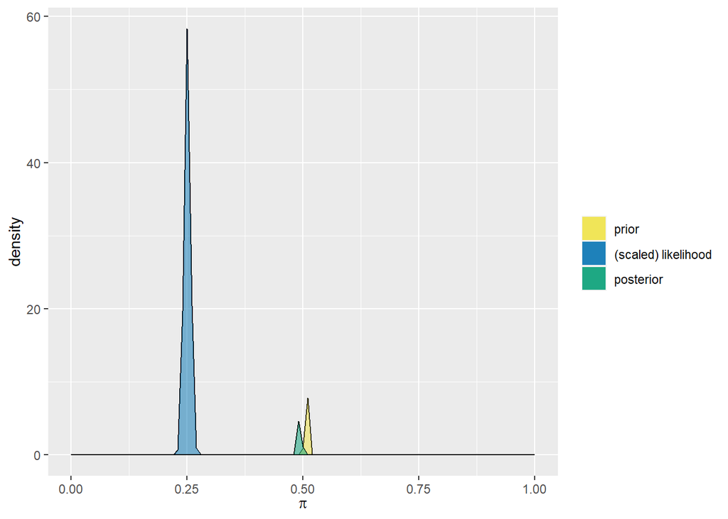

```r
plot_beta_binomial(45000, 44000, 1000, 4000)
```

### Exercises

##### Exercise 4.1 (Match the prior to the description)

going to try to do these on intuition, I could easily plot these with plot_beta and find the right answer, but that seems less useful.

#### a.

Beta(1.8, 1.8) Centering on .5

#### b.

Beta(3, 2) Somewhat favoring pi > .5

#### c.

Beta(1, 10) Strongly favoring pi < .5 (I initially called this somewhat favors instead of stongly favors, but got suspicious and changed after plotting the distribution)

#### d.

Beta(1,3) Somewhat favoring pi < .5

#### e.

Beta(17, 2) Strongly favoring pi > .5

##### Exercise 4.2 (Match the plot to the code)

Seems like (e) should be correct. The prior should have some preference toward pi < .5, and the data should have about a .5 success rate.

Checking…

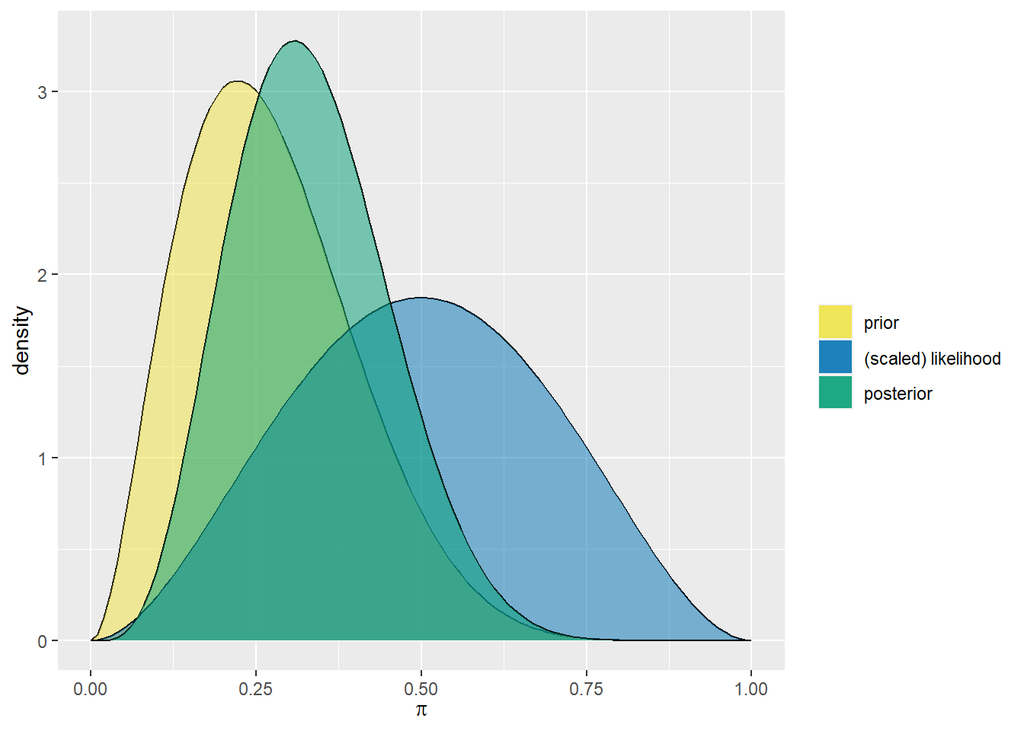

```r
plot_beta_binomial(3, 8, 2, 4)
```

##### Exercise 4.3 (Choice of prior: gingko leaf drop)

#### a.

Ben says that it is really unlikely: Beta(1.5, 10)

#### b.

Albert hates trees and has no idea: Beta(1, 1)

#### c.

Katie thinks based on last year, there is a very high chance: Beta(30, 5)

#### d.

Daryl thinks there’s a decent chance, but he’s somewhat unsure: Beta(4, 1.5)

#### e.

Scott thinks it probably won’t happen, but he’s somewhat unsure: Beta(1.5, 4)

### 4.9.2 Practice: Different priors, different posteriors

##### Exercise 4.4 (Choice of prior)

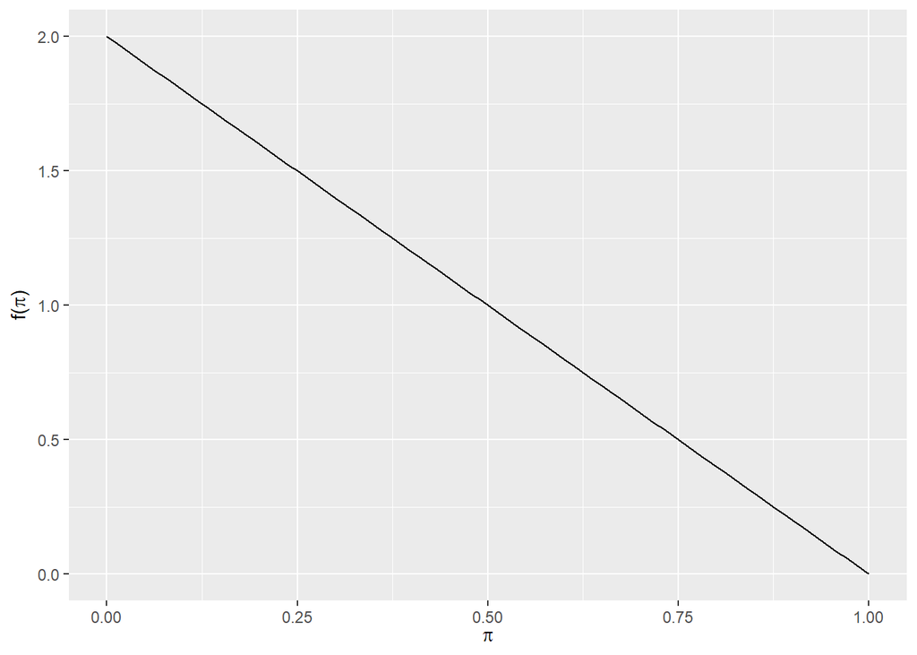

```r
plot_beta(1, 2)
```

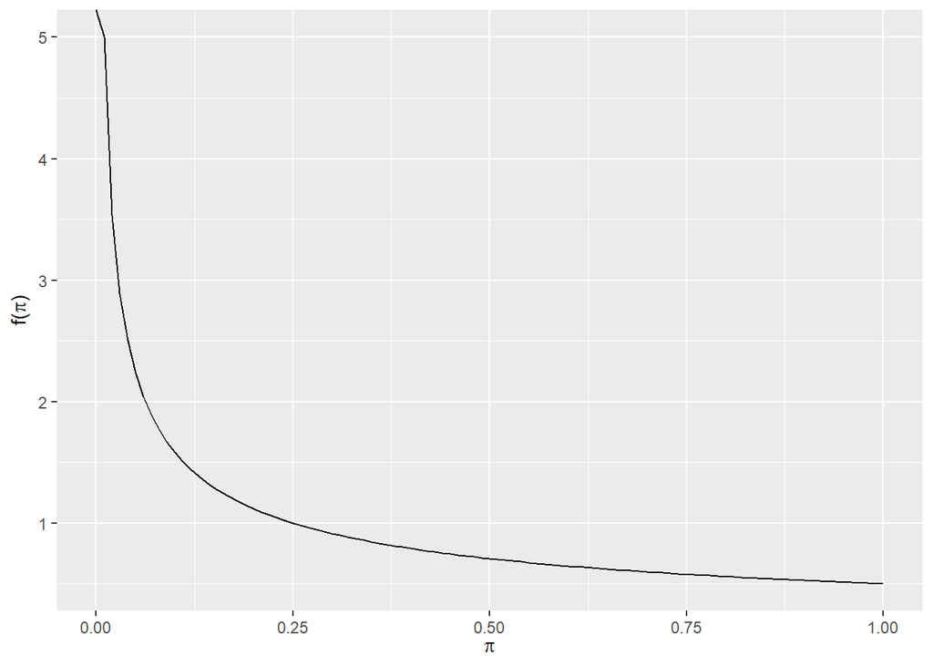

```r
plot_beta(.5, 1)
```

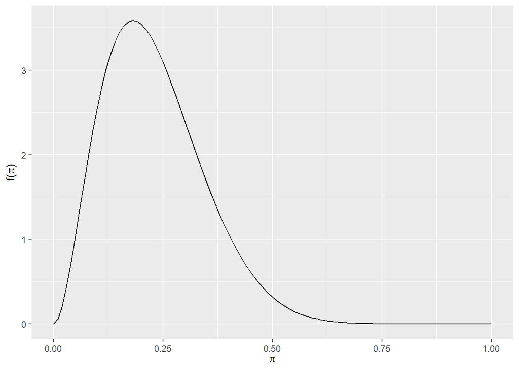

```r
plot_beta(3, 10)
```

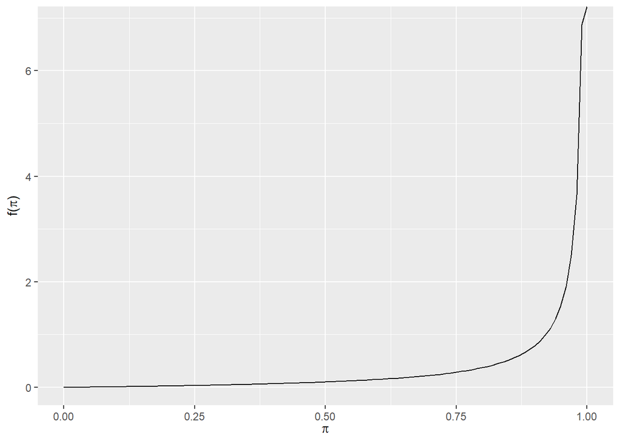

```r
plot_beta(2, .1)
```

Kimya thinks the shop is more likely closed, but isn’t very sure.

Fernando is pretty certain the shop is closed, but concedes there’s a small chance it might be open.

Ciara thinks there’s probably between a 12 and 37 percent chance the shop is open.

Taylor is extremely confident the shop is open.

##### Exercise 4.5 Simulating the posterior

Data (prior?) 3 / 7 days they were open.

```r
summarize_beta(1, 2)
```

```
##        mean mode        var        sd
## 1 0.3333333    0 0.05555556 0.2357023
```

Beta(1, 2) : Kimya’s prior mean was .333

```r
#Calculating Kimya's posterior beta

2 + 7 - 3
```

```
## [1] 6
```

Beta (4, 6)

```r
#getting posterior mean
summarize_beta(4, 6)
```

```
##   mean  mode        var        sd
## 1  0.4 0.375 0.02181818 0.1477098
```

```r
shop <- tibble(status = c("open", "closed"))
```

```r
kimya <-  sample_n(shop, 5000, TRUE, weight = c(.375, .625))

kimya_open <- filter(kimya, status == "open")
nrow(kimya_open)
```

```
## [1] 1883
```

```r
kimya_closed <- filter(kimya, status == "closed")
nrow(kimya_closed)
```

```
## [1] 3117
```

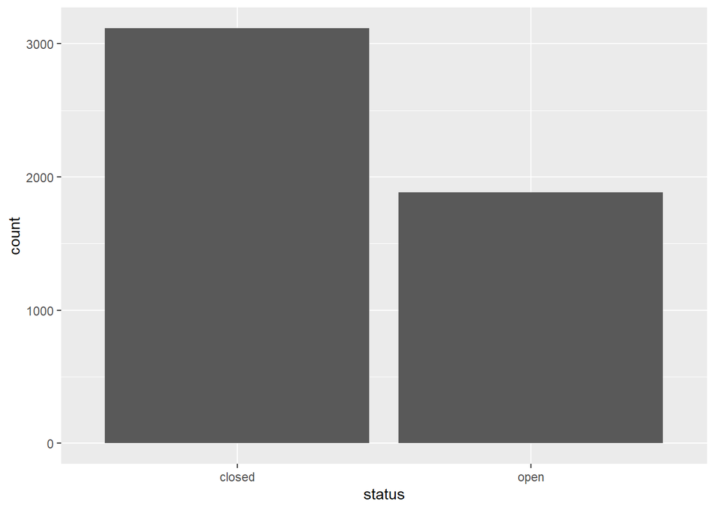

```r
ggplot(data = kimya, mapping = aes(x = status)) +
  geom_bar()
```

So I’m glad I took the time to finally figure out how filter and tibbles work, but I don’t know if this is really what I need to do at all, the question is sort of vague.

I don’t know, maybe there’s not a right answer, I’m going for it. Need to ask for help and come back to this.

Okay got some help from the cohort. Recommendation is to use the simulation section from chapter 3 as a guide.

#### Kimya

```r
#I feel like I sorta understand what this code is doing but not completely.
kimya_sim <- data.frame(pi = rbeta(10000, 1, 2)) |>
  mutate(y = rbinom(10000, size = 7, prob = pi))
```

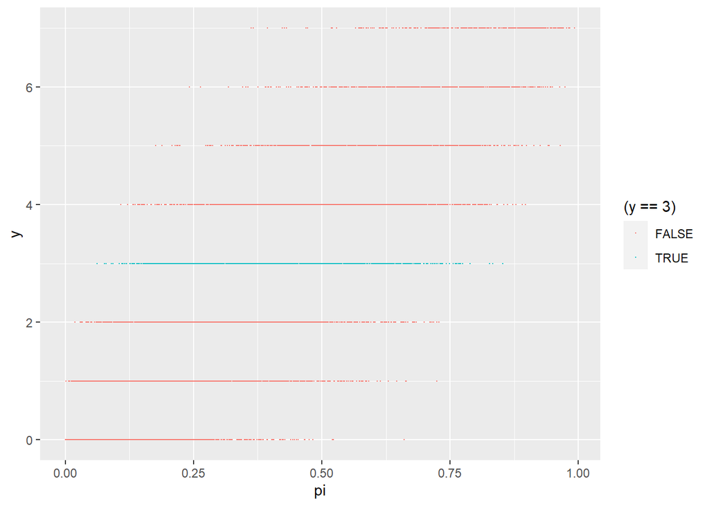

```r
ggplot(kimya_sim, aes(x = pi, y = y)) +
  geom_point(aes(color = (y == 3)), size = .1)
```

#### Fernando

```r
fernando_sim <- data.frame(pi = rbeta(10000, .5, 1)) |>
  mutate(y = rbinom(10000, size = 7, prob = pi))
```

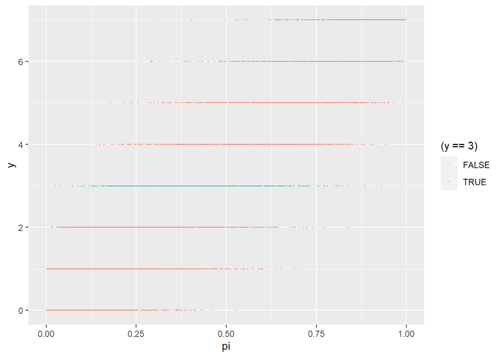

```r
ggplot(fernando_sim, aes(x = pi, y = y)) +
  geom_point(aes(color = (y == 3)), size = .1)
```

#### Ciara

```r
ciara_sim <- data.frame(pi = rbeta(10000, 3, 10)) |>
  mutate(y = rbinom(10000, size = 7, prob = pi))
```

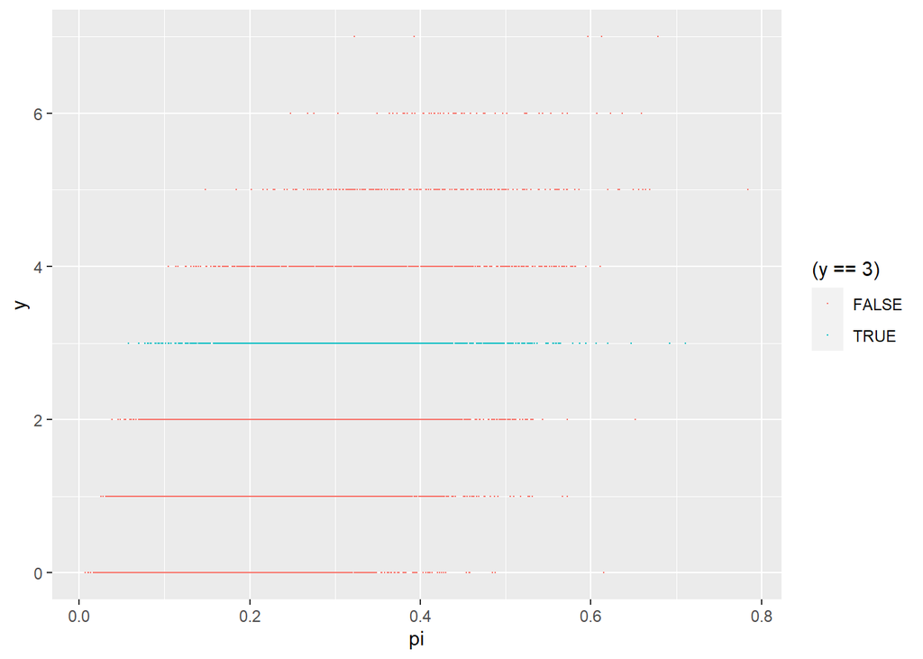

```r
ggplot(ciara_sim, aes(x = pi, y = y)) +
  geom_point(aes(color = (y == 3)), size = .1)
```

Mean ~ .28

#### Taylor

```r
taylor_sim <- data.frame(pi = rbeta(10000, 2, .1)) |>
  mutate(y = rbinom(10000, size = 7, prob = pi))
```

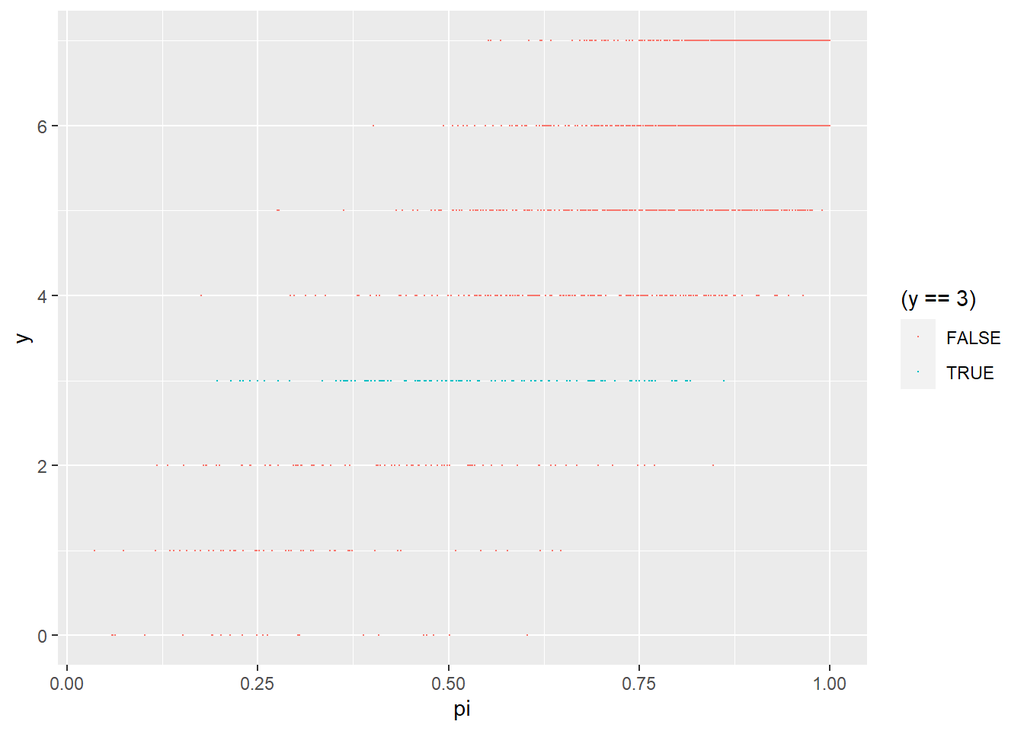

```r
ggplot(taylor_sim, aes(x = pi, y = y)) +
  geom_point(aes(color = (y == 3)), size = .1)
```

Mean ~ .55

##### 4.6 Identifying the Posterior

```r
# identifying the exact posterior model of pi

# Kimya
summarize_beta_binomial(1, 2, 3, 7)
```

```
##       model alpha beta      mean  mode        var        sd
## 1     prior     1    2 0.3333333 0.000 0.05555556 0.2357023
## 2 posterior     4    6 0.4000000 0.375 0.02181818 0.1477098
```

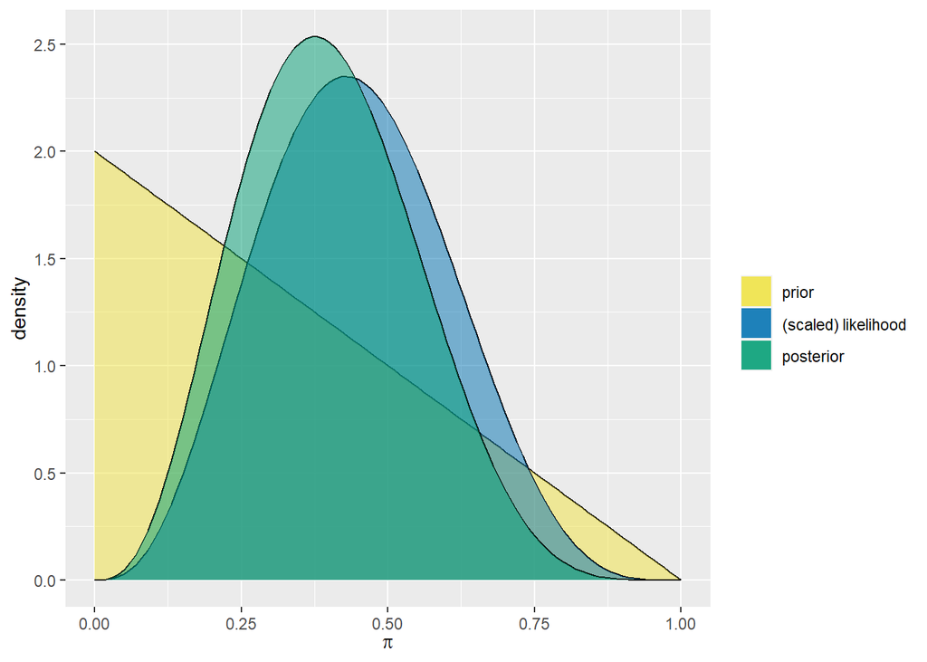

```r
plot_beta_binomial(1, 2, 3, 7)
```

```r
# Fernando
summarize_beta_binomial(.5, 1, 3, 7)
```

```
##       model alpha beta      mean      mode        var        sd
## 1     prior   0.5    1 0.3333333 1.0000000 0.08888889 0.2981424
## 2 posterior   3.5    5 0.4117647 0.3846154 0.02549627 0.1596755
```

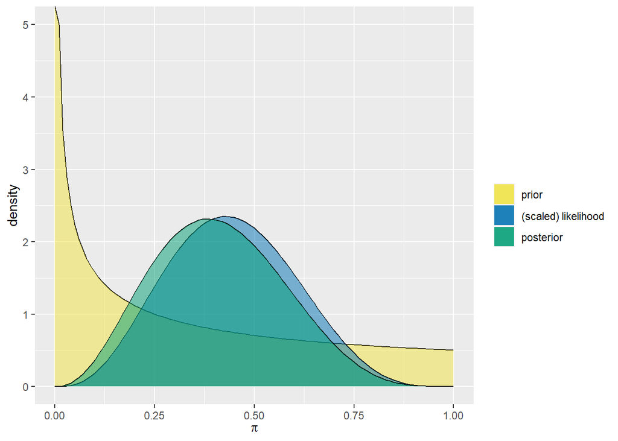

```r
plot_beta_binomial(.5, 1, 3, 7)
```

```r
# Ciara
summarize_beta_binomial(3, 10, 3, 7)
```

```
##       model alpha beta      mean      mode        var        sd
## 1     prior     3   10 0.2307692 0.1818182 0.01267963 0.1126039
## 2 posterior     6   14 0.3000000 0.2777778 0.01000000 0.1000000
```

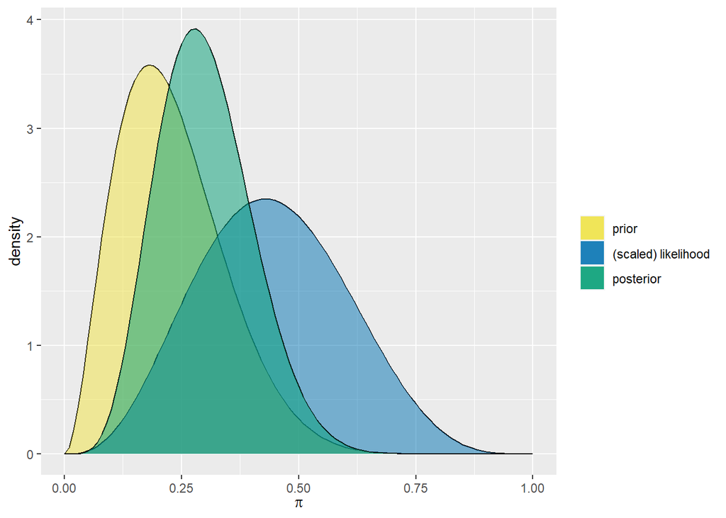

```r
plot_beta_binomial(3, 10, 3, 7)
```

```r
# Taylor
summarize_beta_binomial(2, .1, 3, 7)
```

```
##       model alpha beta      mean      mode        var        sd
## 1     prior     2  0.1 0.9523810 1.0000000 0.01462951 0.1209525
## 2 posterior     5  4.1 0.5494505 0.5633803 0.02451036 0.1565579
```

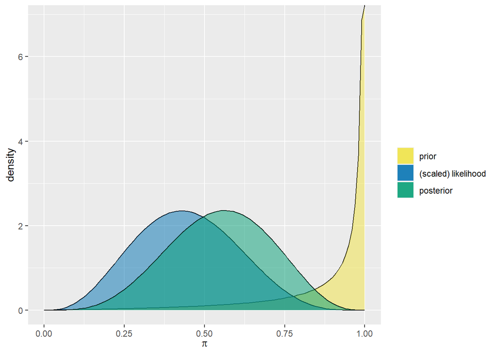

```r
plot_beta_binomial(2, .1, 3, 7)
```

Still need to check with others. I’m not sure I actually understand what this is asking me to do.

Going through before submitting, I do understand this now.

### 4.9.3 Practice: Balancing the data and prior

##### Exercise 4.7 (What dominates the posterior?)

#### a.

```r
summarize_beta_binomial(1, 4, 8, 10)
```

```
##       model alpha beta mean      mode        var        sd
## 1     prior     1    4  0.2 0.0000000 0.02666667 0.1632993
## 2 posterior     9    6  0.6 0.6153846 0.01500000 0.1224745
```

The data has more influence over the posterior.

#### b.

```r
summarize_beta_binomial(20, 3, 0, 1)
```

```
##       model alpha beta      mean      mode         var         sd
## 1     prior    20    3 0.8695652 0.9047619 0.004725898 0.06874517
## 2 posterior    20    4 0.8333333 0.8636364 0.005555556 0.07453560
```

The prior has more influence over the posterior.

#### c.

```r
summarize_beta_binomial(4, 2, 1, 3)
```

```
##       model alpha beta      mean      mode        var        sd
## 1     prior     4    2 0.6666667 0.7500000 0.03174603 0.1781742
## 2 posterior     5    4 0.5555556 0.5714286 0.02469136 0.1571348
```

The prior and data have similar influence over the posterior.

#### d.

```r
summarize_beta_binomial(3, 10, 10, 13)
```

```
##       model alpha beta      mean      mode         var         sd
## 1     prior     3   10 0.2307692 0.1818182 0.012679628 0.11260385
## 2 posterior    13   13 0.5000000 0.5000000 0.009259259 0.09622504
```

The data has more influence over the posterior. Turns out this was wrong, after visualization they are similar.

#### e.

```r
summarize_beta_binomial(20, 2, 10, 200)
```

```
##       model alpha beta      mean      mode         var         sd
## 1     prior    20    2 0.9090909 0.9500000 0.003593245 0.05994368
## 2 posterior    30  192 0.1351351 0.1318182 0.000524097 0.02289316
```

The data has more influence over the posterior.

##### Exercise 4.8 (Visualizing the evolution)

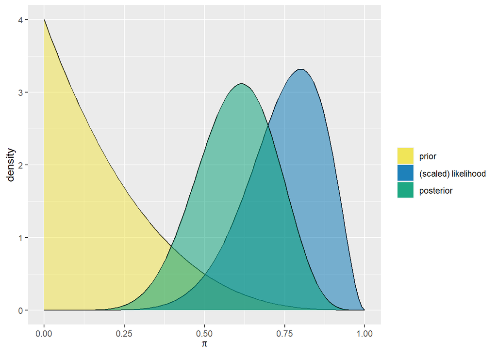

```r
plot_beta_binomial(1, 4, 8, 10)
```

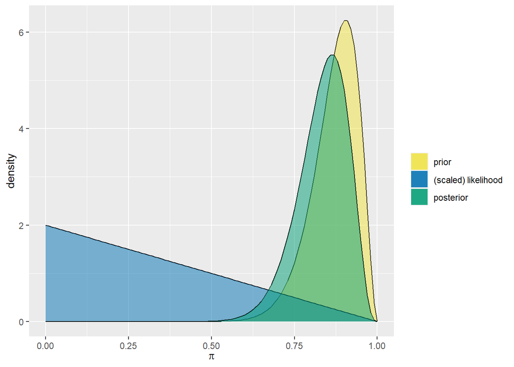

```r
plot_beta_binomial(20, 3, 0, 1)
```

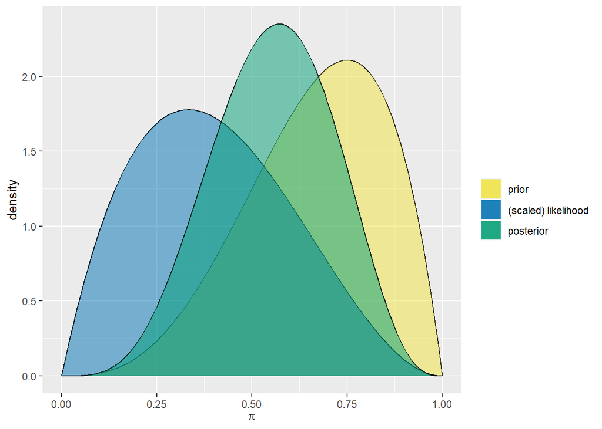

```r
plot_beta_binomial(4, 2, 1, 3)
```

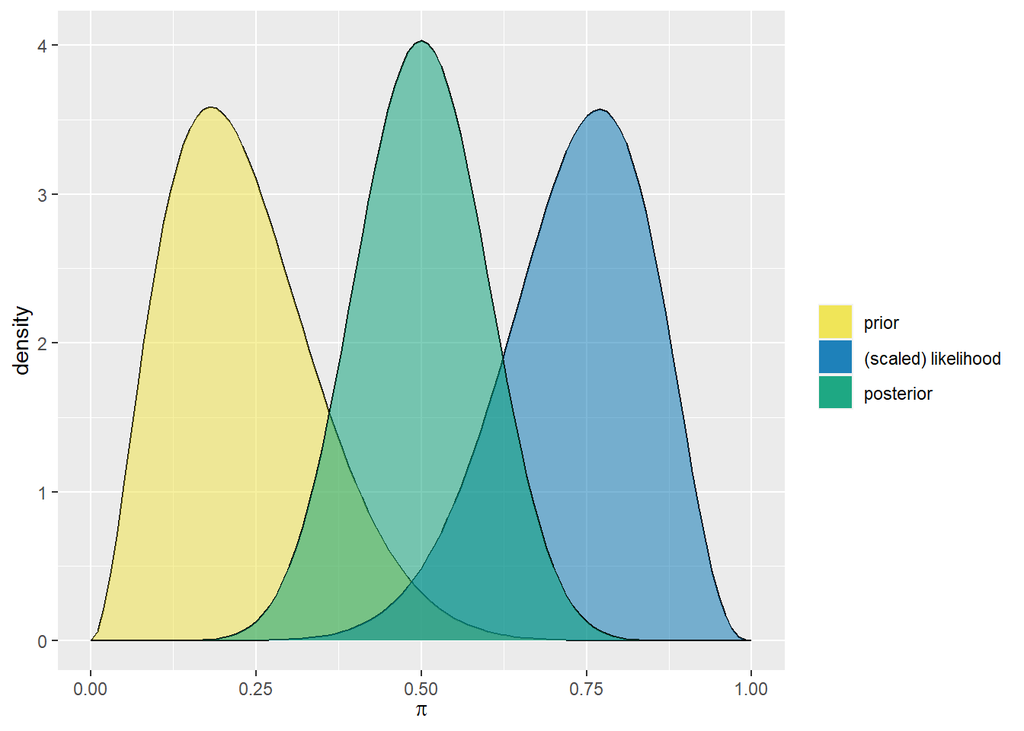

```r
plot_beta_binomial(3, 10, 10, 13)
```

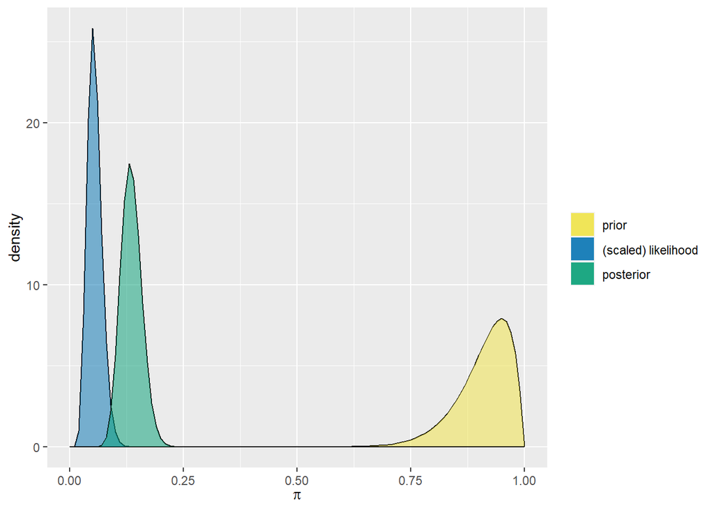

```r
plot_beta_binomial(20, 2, 10, 200)
```

##### Exercise 4.9 (Different data: more or less sure)

Prior Beta for preferring dogs to cats: Beta(7, 2)

#### a.

```r
summarize_beta(7, 2)
```

```
##        mean      mode        var        sd
## 1 0.7777778 0.8571429 0.01728395 0.1314684
```

Trying to do this without looking at the distribution…

So we would expect about 78% of people to prefer dogs, specifically between 65% and 91% (assuming most of the data points are ~ 1 standard deviation from the mean)

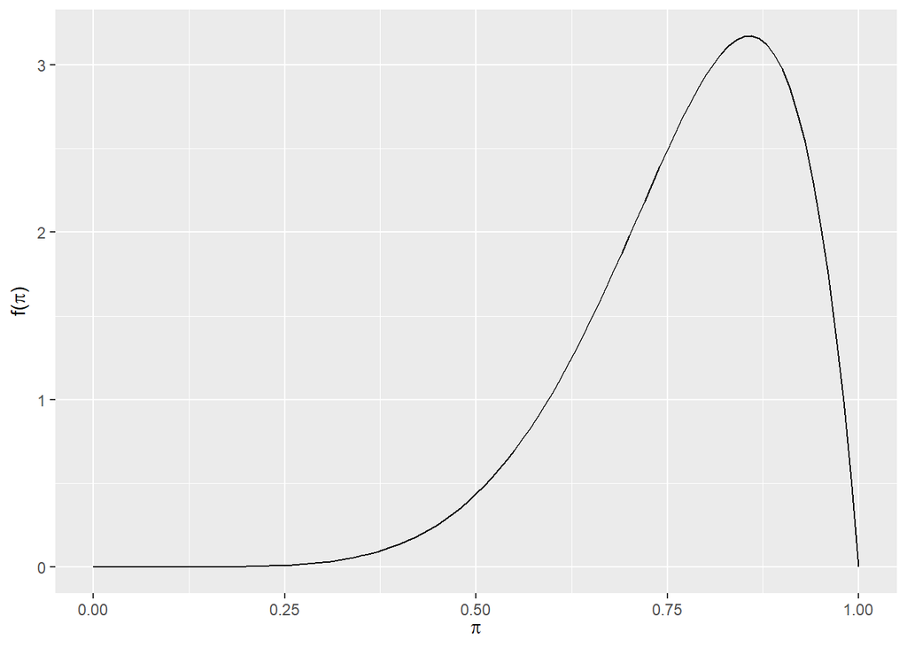

```r
#checking my assumptions based on the summarize_beta output

plot_beta(7, 2)
```

Okay, looks fine, I think for how I was visuallizing this in my head though, thinking about standard deviation from the mode as opposed to the mean might lead to slightly more accurate description of what I’m conveying verbally.

That would be: 86% of people, or 73% to 99%. Maybe these are just rhetorical / descriptive differences. Describing in terms of the mean seems a more accurate way to approach it per the data?

#### b.

Prior Beta(7, 2) Observed data Y = 19 of n = 20

So we had a hit on 95% of those surveyed. This would reinforce our suspicion that there is a high probability of people preferring dogs. The mean might move slightly, perhaps toward 80 - 82%? our certainty should also increase, though not by much, because those these results are significant, there is a small sample size.

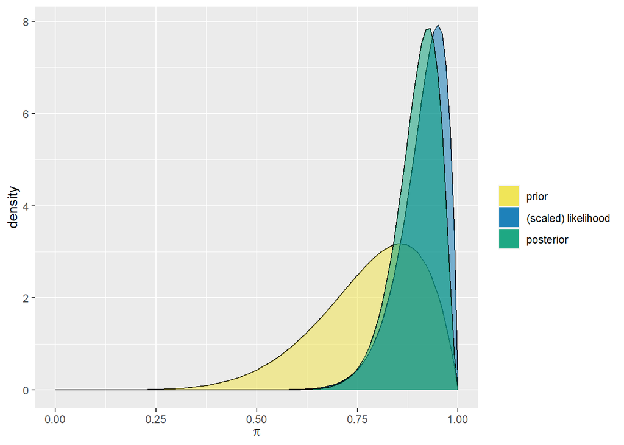

```r
# checking intuition

plot_beta_binomial(7, 2, 19, 20)
```

```r
summarize_beta_binomial(7, 2, 19, 20)
```

```
##       model alpha beta      mean      mode         var         sd
## 1     prior     7    2 0.7777778 0.8571429 0.017283951 0.13146844
## 2 posterior    26    3 0.8965517 0.9259259 0.003091558 0.05560178
```

Okay. So I’m not sure if I underestimated the pull of the data, I think what happened here actually is I overestimated the effect of the prior. I also think I may have factored the sample size in too much.

What if…

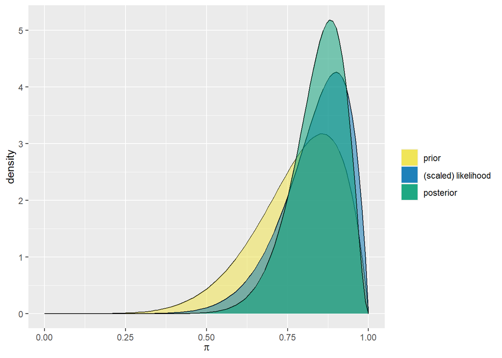

```r
plot_beta_binomial(7, 2, 9, 10)
```

That’s more what I was visualizing. So I think I overestimated the impact of the small sample size.

#### c.

Prior Beta(7,2) Observed Y = 1, n = 20

This is basically just the inverse of the previous question. Though now the data is skewed toward what we didn’t expect as opposed to what we did expect. I think as a result the prior will pull the posterior away from the likelihood.

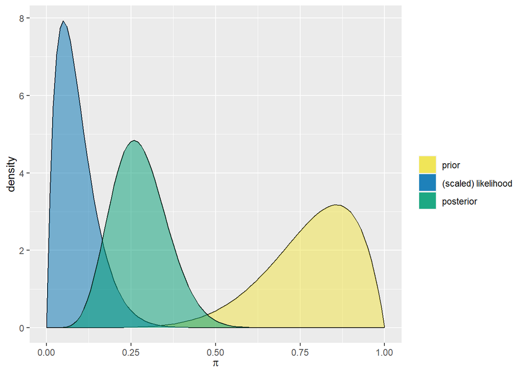

```r
plot_beta_binomial(7, 2, 1, 20)
```

Seems I was right, cool.

#### d.

Prior Beta(7, 2) Observed Y = 10, n = 20

Okay so we should see the mean decrease, these data agree with our prior more than Y = 1, n = 20, but much less than y = 19, n = 20, so I think we should see a pull on the posterior that is between the previous to beta distributions

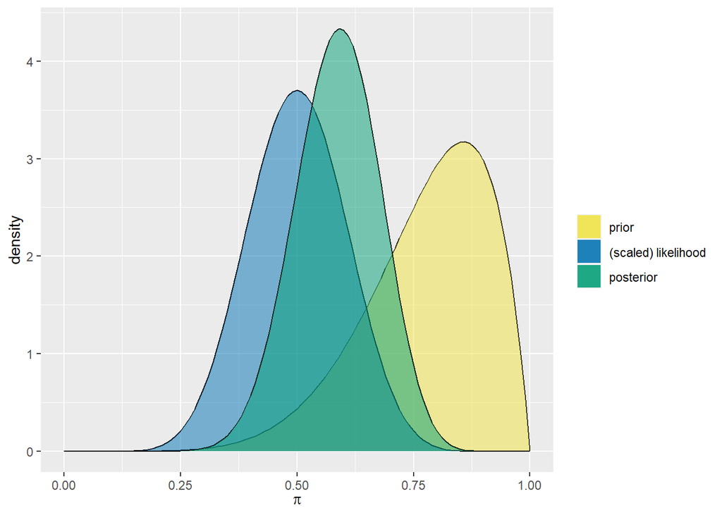

```r
plot_beta_binomial(7, 2, 10, 20)
```

cool.

##### Exercise 4.10 (What was the data?)

#### a.

Prior Beta(.5, .5) Posterior Beta(8.5, 2.5)

```r
summarize_beta_binomial(.5, .5, 8, 10)
```

```
##       model alpha beta      mean              mode        var        sd
## 1     prior   0.5  0.5 0.5000000           0 and 1 0.12500000 0.3535534
## 2 posterior   8.5  2.5 0.7727273 0.833333333333333 0.01463499 0.1209751
```

This took three tries, I tried y = 9, n = 10, as well as 10, 11, before landing on 8, 10

#### b.

Prior beta (.5, .5) Posterior Beta(3.5, 10.5)

So we need low success rate, probably a similar sample size to previous data.

```r
summarize_beta_binomial(.5, .5, 3, 13)
```

```
##       model alpha beta mean              mode    var        sd
## 1     prior   0.5  0.5 0.50           0 and 1 0.1250 0.3535534
## 2 posterior   3.5 10.5 0.25 0.208333333333333 0.0125 0.1118034
```

Three tries again, started at 3, 11, then 3, 12